# Battle of the Giants

### An exploration of the Kaggle Data Science and Machine Learning Survey 2019 results

*An analysis by Andres, Georgios and Luci*

GitHub: laurakah/BattleOfTheGiants

### Looking at the survey results: A comparison between India and the US

- Taking a closer look at these two lone giants in Data Science: **the United States of America as a leading digital nation and India as a rapidly developing tech country.**

### Questions

- **Is India going to be a future superpower in Data Science?**
- What is the state of the art (status quo) in the US and in India regarding programming languages, technologies and Machine Learning?

[interactive chart not shown]

# 1. Demographical exploration

## 1.1 Answer ratio by country

- Two distinct countries: India and the US.
- Ratio of the answers from people from India and people from the US.

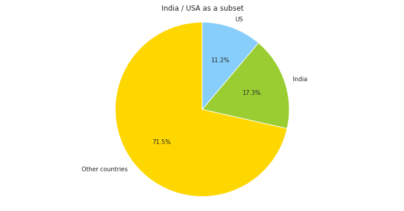

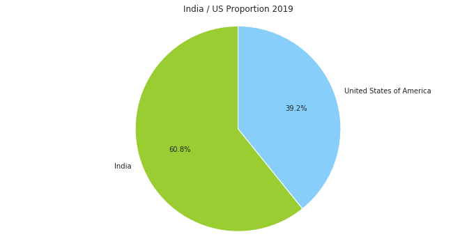

## 1.1.1 Answer ratio by country over time

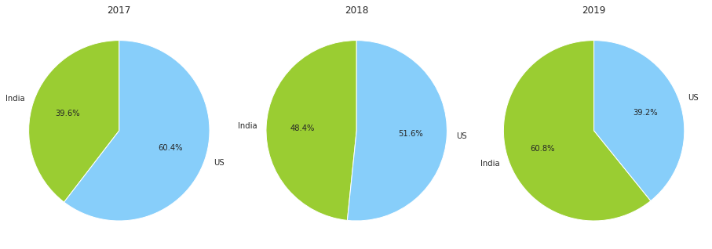

## 1.2 Gender ratio

- Still encountering a significant difference in the ratio between men, females and other genders in tech

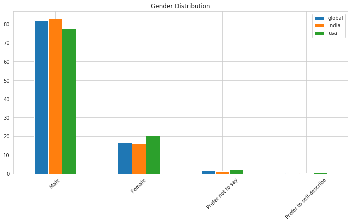

## 1.3 Age distribution

- Having a look at the age distribution in India, in the US and globally in comparison

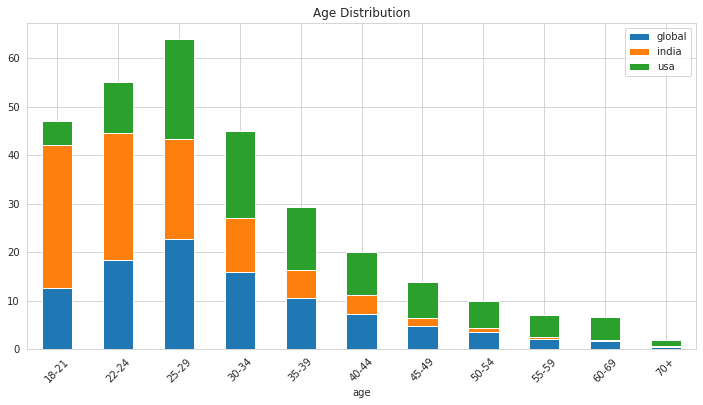

# 2. Data Science in India and the US

## 2.1 Highest educational degree

- Assumptions: the age distribution will reflect in the distribution of educational degrees (more people with lower degrees in India compared to the US)

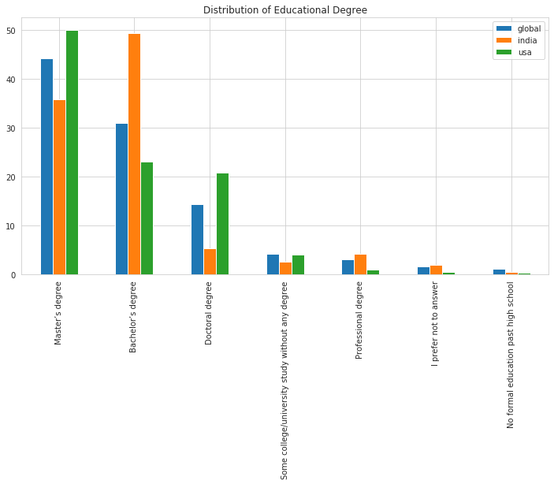

## 2.2 Current job position

- Assumption: a relatively high percentage of students in India compared to the US

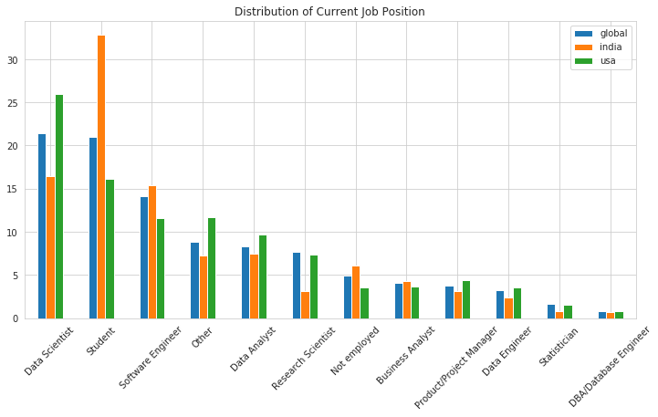

## 2.3 Salary

- Assumption: due to age and educational degree the distributions will differ between US and India

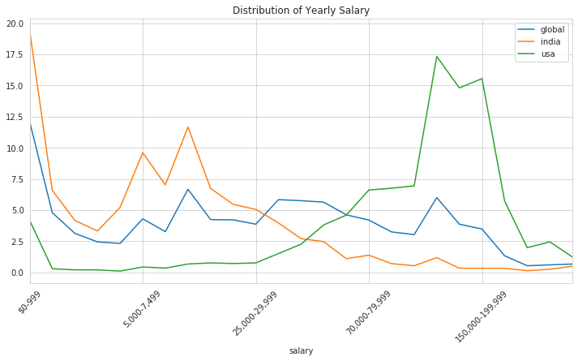

# 3. Tools and technologies

## 3.1 Programming languages

- Tools and technologies used in the Data Science context and see if they differ between India and the US
- The popularity of different programming languages can help young Data Scientists decide which languages to practice first.

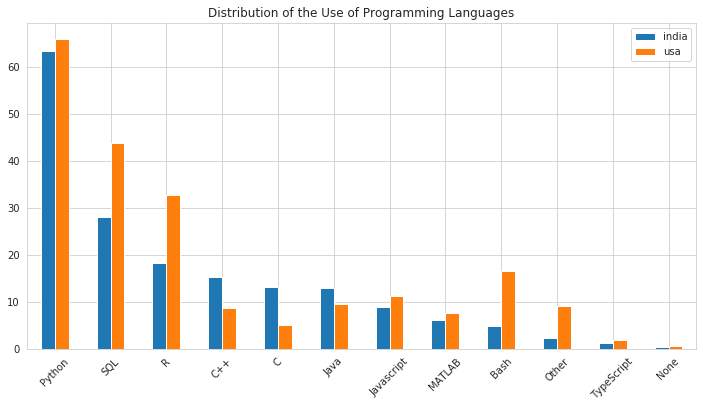

## 3.2 Programming experience

- Programming experience in years in conjunction with age and degree as an indicator for the time the surveys participants have been interested in or practicing Data Science
- Assumptions: we expect a high percentage of people from India with less programming experience and a more flat distribution for people in the US.

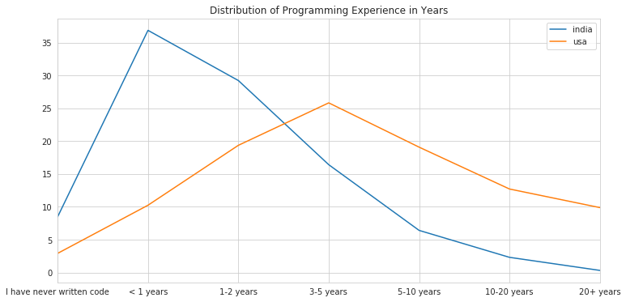

## 3.3 Machine Learning experience

- Machine learning experience in years as an indicator for a digital transformation towards machine learning
- Assumption: we assume a high percentage of people from India having a shorter machine learning experience in comparison to people from the US.

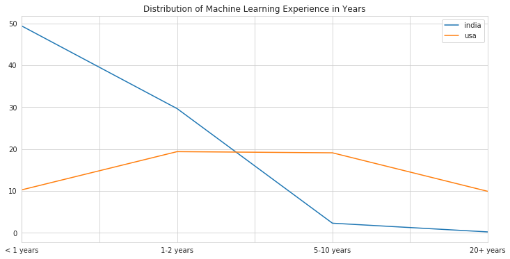

## 3.4 Machine learning algorithms

- We wanted to know if there are any differences in the distribution of machine learning algorithms between India and the US

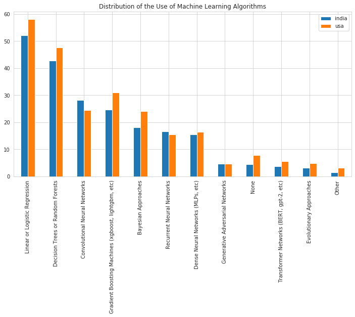

## 3.5 Learning Resources

- Which resources do participants use to learn about Data Science related topics

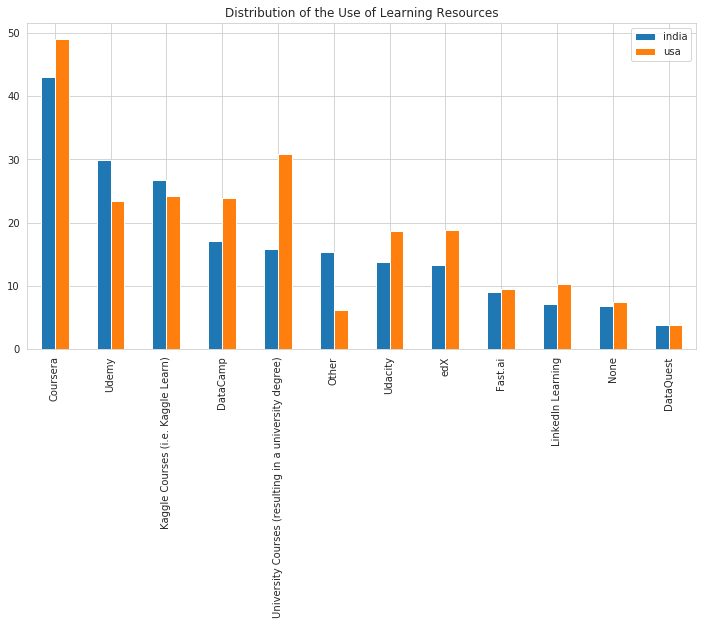

# Summary

### Is India going to be a future superpower in Data Science?

Based on the analysis of selected features we showed, that India has the potential to be an upcoming Data Science superpower and can have a high impact on the future of Data Science globally.

1. The ratio of Indian participants in the survey grew compared to the ratio of US participants by 20% from 2017 to 2019. Assuming these Indian participants are interested, apply or support digital technologies they increase their contrubution to digital sciences.
2. Most of the Indian participants are younger (<25 years) and have less experience in Data Science and Machine Lerning than US participants with the same age, but they provide twice as many young developers.
3. Indian participants are morelikley to have a lower education degree than US participants. This could be derived by the assumption, that for learning Data Science nowdays you just need a digital device and no educational infrastructure.

### How is the state of the art (status quo) in US and India regarding programming languages, technologies and Machine Learning algorithms?

1. Within both India and the US Python is the programming language most participants use. In the US higher percentages of programmers use SQL, R and Bash than in India.

# What's next:

- Evaluate the industries and company fields currently applying Data Science
- How to measure the impact of Data Science on different industries and countries
- Predicting trends and developments in Data Science

# Thank you for your attention!